# Associative Statistics

##### Libraries

```r
# ============================
# Data Manipulation / Databases
# ============================
library(tidyverse)   # Collection of packages for data manipulation (dplyr, tidyr) and visualization (ggplot2)
library(dplyr)       # Data manipulation: filtering, summarizing, joining
library(plyr)        # Older data manipulation package (mostly superseded by dplyr)
library(dbplyr)      # Interface to translate dplyr syntax to SQL for databases

# ============================
# Descriptive Statistics & Visualization
# ============================
library(ggplot2)     # Flexible and powerful plotting system
library(ggpubr)      # Easy-to-use publication-ready plots with ggplot2 enhancements
library(lattice)     # Alternative plotting system for multi-panel plots
library(descr)       # Descriptive statistics: frequency tables, crosstabs
library(Rmisc)       # Utility functions for summaries: mean, SE, CI
library(knitr)       # Dynamic report generation, integration with R Markdown
library(kableExtra)  # Enhanced tables for knitr and R Markdown
```

##### Import Data

```r
dataseniors<-read.csv2("seniors2.csv", sep=";", dec=",")#read data
data.df<-data.frame(dataseniors[1:310,1:31])#data frame(rectangular data structures)
```

## Associative Analysis

There are statistical procedures, termed **associative analysis**, which determine answers to questions about the relationship between different variables. Associative analysis determines whether stable relationships exist between two variables.

- Relation or association does not imply causality
- relationships are linear vs non-linear and monotonic vs non-monotonic

**Properties of a Relationship:**

- Presence: refers to whether any systematic relationship exists between the two variables of interest. Determined by statistical significance.
- Strength: means you know how consistent the relationship is (strong, moderate, weak or nonexistent).
- Direction: means that you know if the relationship is positive or negative.

## Linear relationships

[figure not shown]

- Quantitative variables
- can be modeled as a straight line
- Direct Relationship: positive (as one variable increases, the other increases)
- Inverse Relationship: negative (as one variable increases, the other decreases)
- All linear relationships are monotonic, but not all monotonic relationships are linear

### Non-linear (or curvilinear) relationship

[figure not shown]

- Quantitative variables
- one variable is associated with another variable, but the relationship is described by a curve rather than a straight line
- they are **monotonic** only if the relationship consistently goes in one direction (either always increasing or always decreasing), but not necessarily at a constant rate

### Monotonic Relationship

[figure not shown]

- Quantitative variables
- assign a general direction to the association between the two variables (increasing or decreasing)
- A monotonic relationship is when two variables tend to move in the same relative direction
- meaning as one variable increases, the other consistently increases or consistently decreases
- the direction does not have to be constant, which is the main difference between a linear relationship

### Non-monotonic Relationship

[figure not shown]

- Nominal variables
- the presence (or absence) of one variable is systematically associated with the presence (or absence) of another variable.
- a complex correlation where the relationship between two variables changes direction, meaning one variable’s effect on another is not consistently increasing or decreasing
- For example, a “U”-shaped curve is nonmonotonic because the dependent variable initially decreases as the independent variable increases, then increases again after a certain point

## How to Study Nominal Relationship

### Crosstabulation and Chi-Square Test (Qualitative Variables)

- **Chi-square analysis** is the examination of frequencies for two nominal-scaled variables in a cross-tabulation table to determine whether the variables have a nonmonotonic relationship

#### Example

Is gender proportional to age?

H0: RankA and age are not related.

H1: RankA and age are related.

Gender (expected)

|  | male | female |  |
| --- | --- | --- | --- |
| young | 25 | 25 | 50 |
| old | 25 | 25 | 50 |
|  | 50 | 50 |  |

Gender (actual)

|  | male | female |  |
| --- | --- | --- | --- |
| young | 0 | 50 | 50 |
| old | 50 | 0 | 50 |
|  | 50 | 50 |  |

##### Balloon Plot

A balloon plot is a data visualization that uses a grid to represent a contingency table, where the size of a colored circle (or “balloon”) in each cell corresponds to the magnitude of the data in that cell. They are useful for comparing multiple groups and visualizing the relative frequencies of different categories, especially in large datasets.

This kind of visualization helps you quickly see:

- Whether **categories are evenly distributed** across groups.
- If there’s a **relationship** (association) between variables — e.g., if one gender is more likely to have higher education.
- Whether some category combinations are rare or overrepresented.

```r
library(gplots) # For balloonplot
library(lsr) # For Cramers'V

# 1. Contingency table for RankA and age
ConTtable<-table(data.df$rankA,data.df$age)
RConTtable<-prop.table(ConTtable)*100

# 2. Graphical visualization of the table.
balloonplot(t(RConTtable), main ="rankA", xlab ="", ylab="",
            label = FALSE, show.margins = FALSE)
```

[figure not shown]

However, we want to calculate the chi-square statistic in order to confirm.

- actual difference = Σ(actual value - estimated value)2 / n

```r
# chi square test
chisq.test(data.df$rankAA,y=data.df$age)
```

```
    Pearson's Chi-squared test

data:  data.df$rankAA and data.df$age
X-squared = 28.428, df = 8, p-value = 0.0003993
```

```r
# cramers V
cramersV(ConTtable)
```

```
[1] 0.07960765
```

## How to Study Quantitative Relationships

- **Covariation** is defined as the amount of change in one variable systematically associated with a change in another variable. Depends on the unit of measure and, therefore, determines presence (and direction) but not strength of the relationship.
  - Σ(xi - x̄) * (yi - ȳ) / n
- **The correlation coefficient** is an index number, constrained to fall between the range of -1 and 1, that communicates both the strength and the direction of association between two variables.
  - The amount of association between two variables is communicated by the absolute size of the correlation coefficient, whereas its sign communicates the direction of the association
  - changing the units will change the covariance greatly
  - Σ(xi - x̄) * (yi - ȳ) / n * sx * sy

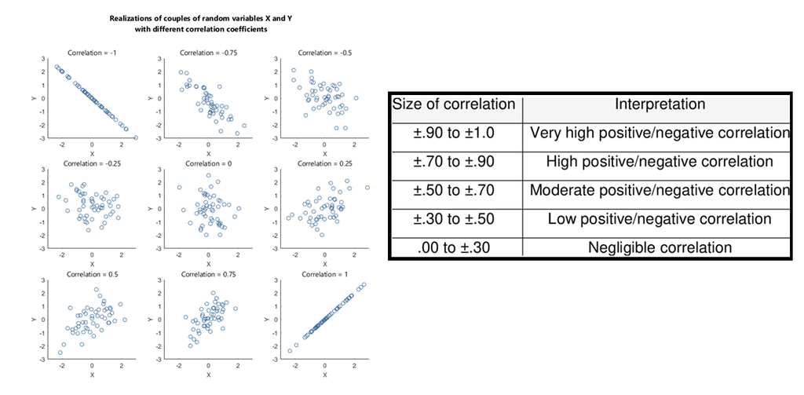

### Correlogram

The correlogram is a commonly used tool for checking randomness in a data set. A correlogram is a graphical representation used to visualize the correlation between variables, most commonly in time series data. In time series analysis, it displays the autocorrelation function, showing how a series is correlated with its lagged (past) values.

For multivariate datasets, it can be a correlation matrix visualization where the relationships between pairs of variables are shown with colors or scatterplots. Correlograms help in identifying patterns like trends and seasonality, checking for randomness, and assisting in model selection.

#### Correlation Matrix Plot

Use this before plotting to check if the variables have a relationship before modeling. You can also use it to check for multi-collinearity (where two or more independent variables are highly correlated, meaning one can be linearly predicted from the others).

```r
library(Hmisc)
library(corrplot)
library(PerformanceAnalytics)
```

```r
data.dfB<-data.frame(dataseniors[1:310,2:13])
#Correlation matrix
res <- round(cor(data.dfB),2)
#correlation matrix with p-values
res2 <- rcorr(as.matrix(data.dfB))
res2
```

If random, autocorrelations should be near zero for any and all time-lag separations. If non-random, then one or more of the autocorrelations will be significantly non-zero.

```r
#Visualization of the data matrix
corrplot(res, type = "upper", order = "hclust",
         tl.col = "black", tl.srt = 45)
```

[figure not shown]

Each variable (innov, implus, risk, etc) is compared pairwise with every other variable to measure how strongly they are linearly correlated. The **correlation coefficient (r)** ranges from **–1 to +1**:

- **+1** → perfect positive correlation
- **0** → no linear correlation
- **–1** → perfect negative correlation

What the colors mean:

- dark blue indicates a strong positive correlation
- dark red indicates a strong negative correlation
- lighter colors indicate weak or no correlation

What the circle size means:

- the larger the circle, the strong the correlation
- smaller or faint circles indicate a weaker correlation

#### Matrix of Scatterplots

When analyzing many variables, scatter plots and correlation coefficients can quickly uncover patterns and reduce a large amount of data to a subset of interesting relationships.

```r
#Matrix of scatter plots.
my_data <- data.dfB[ c('price','coup','sale','value','primav')]
chart.Correlation(my_data, histogram=TRUE,pch="+")
```

[figure not shown]

### Linear Regression

A regression model is a statistical tool that estimates the relationship between a dependent variable (Y) and one or more independent variables (X).

- X1, X2, etc are my independent, explanatory, or exogenous variables
- Y is my dependent, response, or endogenous variable

#### Simple Linear Regression

[figure not shown]

A simple linear regression model is a statistical method used to find a linear relationship between a single independent variable (x) and a single dependent variable (y). It does this by fitting the best-fit straight line through a scatter plot of the data.

- Yi is the value of the dependent variable Y when random variable X takes a specific value xi
- xi is the specific value of the random variable X
- ui is an error, a random variable that is assumed to be normal with mean 0 and unknown variance σ2
- β0 is the population intercept
- β1 is the population slope
- Yi = β0 + β1xi + ui

This is the formula for the regression line:

ŷ = B̂0 + B̂1x

The model assumes:

- Linearity: The underlying relationship between X and Y is linear
- Homogeneity: The errors have mean zero
- Homoscedasticity: The variance of the errors is constant
  - The variance of the residuals is constant across all levels of the independent variables. This is also known as the equal variance assumption.
  - Example of Homoscedasticity:

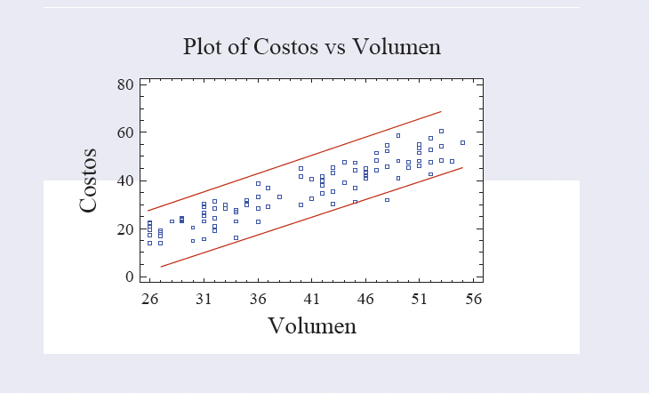

  - Example of non-Homoscedasticity:

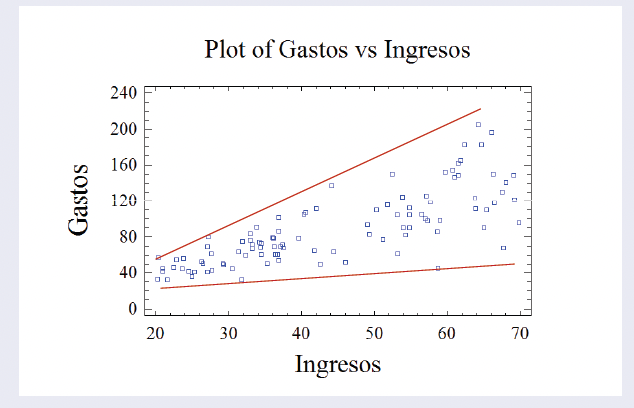

- Independence: The errors are independent
  - One observation doesn’t imply any information about another.
  - The residuals (errors) are independent of each other, and the observations are independent from one another. This means one residual should not influence another.
  - Time series are interdependent
- Normality: The errors follow a normal distribution
  - The residuals are normally distributed. This means the distribution of the errors should be bell-shaped around a mean of zero.

##### **Generate the Linear Model, Residuals, and Coefficients**

H_0: Price does not predict coup

H_1: Price predicts coup (which might represent coupon usage, purchase likelihood, or similar behavior).

```r
ggplot(data.df,aes(x=price, y=coup)) +
  geom_point() +
  geom_smooth(method='lm')
```

[figure not shown]

```r
model <- lm(data.df$coup~data.df$price) # linear model function
summary(model) # returns residuals, coefficients, etc
```

```
Call:
lm(formula = data.df$coup ~ data.df$price)

Residuals:
    Min      1Q  Median      3Q     Max
-2.8447 -0.8243  0.0515  0.8548  3.2533

Coefficients:
              Estimate Std. Error t value Pr(>|t|)
(Intercept)    0.73119    0.29541   2.475   0.0139 *
data.df$price  0.75388    0.07344  10.265   <2e-16 ***
---
Signif. codes:  0 '***' 0.001 '**' 0.01 '*' 0.05 '.' 0.1 ' ' 1

Residual standard error: 1.234 on 308 degrees of freedom
Multiple R-squared:  0.2549,    Adjusted R-squared:  0.2525
F-statistic: 105.4 on 1 and 308 DF,  p-value: < 2.2e-16
```

**Interpretation**

When `price = 0`, the predicted value of `coup` is 0.731. (Not necessarily meaningful if `price=0` isn’t realistic.)

The t-value is 10.265 and the p-value is <2e-16. This means we reject the null hypothesis and accept that price predicts coup.

**Goodness of Fit**

- **Multiple R-squared = 0.2549**
  - About **25.5% of the variation** in `coup` is explained by `price`.
  - This suggests a **moderate** linear relationship — meaningful but not perfect.
- **Adjusted R-squared = 0.2525**
  - Adjusts for model complexity (here it’s basically the same since it’s a simple regression).
- **Residual Std. Error = 1.234**
  - On average, the model’s predictions deviate from actual `coup` values by about 1.23 units.
- **F-statistic = 105.4, p < 2.2e-16**
  - Confirms that the regression model as a whole is highly significant.

##### **Predictions**

The `predict()` function in R takes a **fitted model** and produces **predicted outcomes** — i.e., what your model expects the dependent variable to be, based on the independent variables.

```r
predict(model, newdata = data.df) # predictions?
```

You can use this to add predictions to the dataset, compare actual and predicted values, and comute residuals.

```r
yhat = predict(model, newdata = data.df) # yhat is the predicted value on the regression line
```

The above code calculates all the predicted values based on the regression.

```r
# residuals
e = data.df$coup - yhat
e
```

This code calculates the residuals. This is helpful for checking the validity of the model. If the residuals are small and centered around zero, the model predicts well. If the residuals are large or biased (mostly positive or negative), the model is wrong.

```r
# confidence intervals for new values
x<-data.df$price
model<-lm(data.df$coup~x)
predict(model,data.frame(x=c(1,90)), interval ="confidence")
```

```
        fit       lwr       upr
1  1.485069  1.042844  1.927293
2 68.580321 56.137729 81.022913
```

```r
predict(model,data.frame(x=c(1,90)), interval ="prediction")
```

```
        fit        lwr      upr
1  1.485069 -0.9837832  3.95392
2 68.580321 55.9028698 81.25777
```

We can then calculate confidence intervals for each new predicted point to give an average predicted value of coup at value price.

#### Multiple Linear Regression

[figure not shown]

β= (X′X)−1X′Y

Assumptions:

- Linearity: The underlying relationship between X1, …,Xk and Y is linear
- Homogeneity: The errors have mean zero,E[ui ] = 0.
- Homoscedasticity: The variance of the errors is constant,Var (ui ) = σ2.
- Independence: The errors are independent
- Normality: The errors follow a normal distribution, ui ∼ N(0, σ2).
- Full rank: The matrix of regressors X = [1, X1, . . . ,Xk ] has full column rank, rank(X) = k + 1.
- Sample size condition: The number of observations exceeds the number of parameters, n > k.

##### **Generate the Linear Model, Residuals, and Coefficients**

```r
data<-read.csv2("seniors2.csv")
data.df<-data.frame(data[1:310,2:31])
model<-lm(coup~price+education+value+sale+gender+age,data=data.df) # coup is y and all other are x variables
summary(model)
```

```
Call:
lm(formula = coup ~ price + education + value + sale + gender +
    age, data = data.df)

Residuals:
    Min      1Q  Median      3Q     Max
-3.0949 -0.5959  0.0345  0.5803  2.4607

Coefficients:
                            Estimate Std. Error t value Pr(>|t|)
(Intercept)                -0.447279   0.308211  -1.451  0.14776
price                       0.182575   0.070812   2.578  0.01040 *
educationHigh school        0.083789   0.170740   0.491  0.62397
educationUniversity degree -0.047997   0.189231  -0.254  0.79994
value                       0.288089   0.059955   4.805 2.44e-06 ***
sale                        0.593579   0.059466   9.982  < 2e-16 ***
gendermale                 -0.341755   0.113456  -3.012  0.00281 **
age50-59y                   0.001912   0.134795   0.014  0.98869
age60-60y                   0.202801   0.144200   1.406  0.16064
---
Signif. codes:  0 '***' 0.001 '**' 0.01 '*' 0.05 '.' 0.1 ' ' 1

Residual standard error: 0.9437 on 301 degrees of freedom
Multiple R-squared:  0.5744,    Adjusted R-squared:  0.5631
F-statistic: 50.79 on 8 and 301 DF,  p-value: < 2.2e-16
```

As we increase one unit in price, the average value of coup will increase 0.18.

We use the residual variance, but you could use a confidence variable or use a hypothesis test for this. This will come later.

#### ANOVA P-Value for Every Variable

```r
# Fit the full model
full.model <- lm(coup ~., data = data.df)
summary(full.model)
```

```
Call:
lm(formula = coup ~ ., data = data.df)

Residuals:
     Min       1Q   Median       3Q      Max
-2.94780 -0.47441 -0.00663  0.56522  2.27157

Coefficients:
                            Estimate Std. Error t value Pr(>|t|)
(Intercept)                 0.071962   0.707556   0.102 0.919065
conv                       -0.127570   0.053802  -2.371 0.018429 *
brand                       0.052634   0.051576   1.021 0.308393
impuls                     -0.034200   0.057403  -0.596 0.551815
innov                       0.129735   0.073999   1.753 0.080690 .
prest                       0.056099   0.064259   0.873 0.383423
price                       0.171955   0.074092   2.321 0.021032 *
primav                      0.026971   0.059556   0.453 0.651011
priqua                     -0.059956   0.047375  -1.266 0.206744
risk                       -0.094221   0.068382  -1.378 0.169376
sale                        0.621582   0.064667   9.612  < 2e-16 ***
value                       0.213146   0.063511   3.356 0.000903 ***
Drawing                    -0.008796   0.032340  -0.272 0.785854
Reading                     0.063522   0.040269   1.577 0.115858
Music                      -0.068400   0.047224  -1.448 0.148649
Sport                       0.028751   0.033392   0.861 0.389979
Studying                   -0.007868   0.038177  -0.206 0.836876
Television                  0.105165   0.043207   2.434 0.015574 *
Going.out                  -0.072108   0.044376  -1.625 0.105330
Cultural                    0.004608   0.042778   0.108 0.914301
walking                     0.006569   0.039355   0.167 0.867553
gendermale                 -0.390477   0.143247  -2.726 0.006827 **
mrhpyes                    -0.189271   0.145277  -1.303 0.193730
placecountryside           -0.268723   0.171726  -1.565 0.118781
placesuburbs                0.086558   0.151738   0.570 0.568845
numfamily                   0.065239   0.057121   1.142 0.254408
age50-59y                  -0.190724   0.155444  -1.227 0.220894
age60-60y                   0.049348   0.176613   0.279 0.780139
educationHigh school        0.175198   0.183271   0.956 0.339944
educationUniversity degree  0.102363   0.212739   0.481 0.630783
income>3750                -0.755443   0.325180  -2.323 0.020906 *
income1250-1875            -0.126170   0.174960  -0.721 0.471442
income1876-2500             0.024225   0.180850   0.134 0.893539
income2501-3750            -0.175545   0.205486  -0.854 0.393693
incomeNot answer            0.056672   0.187379   0.302 0.762544
rankA                      -0.162722   0.097413  -1.670 0.095978 .
rankAA                      0.117256   0.098396   1.192 0.234423
---
Signif. codes:  0 '***' 0.001 '**' 0.01 '*' 0.05 '.' 0.1 ' ' 1

Residual standard error: 0.9078 on 273 degrees of freedom
Multiple R-squared:  0.6428,    Adjusted R-squared:  0.5957
F-statistic: 13.65 on 36 and 273 DF,  p-value: < 2.2e-16
```

##### Refine the Model

```r
# new model
new.model <- lm(coup ~conv+price+sale, data = data.df)
summary(new.model)
```

```
Call:
lm(formula = coup ~ conv + price + sale, data = data.df)

Residuals:
    Min      1Q  Median      3Q     Max
-3.4850 -0.6167 -0.0419  0.6531  2.4913

Coefficients:
            Estimate Std. Error t value Pr(>|t|)
(Intercept)  0.31816    0.32054   0.993   0.3217
conv        -0.10843    0.05457  -1.987   0.0478 *
price        0.28394    0.06855   4.142 4.45e-05 ***
sale         0.74550    0.05613  13.282  < 2e-16 ***
---
Signif. codes:  0 '***' 0.001 '**' 0.01 '*' 0.05 '.' 0.1 ' ' 1

Residual standard error: 0.9863 on 306 degrees of freedom
Multiple R-squared:  0.5274,    Adjusted R-squared:  0.5227
F-statistic: 113.8 on 3 and 306 DF,  p-value: < 2.2e-16
```

Intercept

When conv, price, and sale are all zero, the predicted value of coup is 0.318.

Conv

For each unit increase in convenience, the predicted coup decreases by 0.108, holding price and sale constant. The p-value (0.0478) is smaller than alpha, meaning this effect is statistically significant, but small.

Price

For each unit increase in price, coup increases by 0.284, holding conv and sale constant. The p-value (<0.001) is smaller than alpha, meaning this effect is highly significant.

Sale

For each unit increase in sale, coup increases by 0.746, holding conv and price constant. The p-value (<2e-16) is extremely significant.

Residuals

The residuals have a median of -0.041, which is close to zero. The spread from -3.485 to 2.491 is balanced, meaning no major skew or bias.

The multiple R-squared indicates that the model explains 52.74% of the variation, which indicates a moderate to strong relationship.